# Risk Factor Analysis

## Outcome Variable

**Outcome Variable:** ever_wasted

## Predictor Variables

**Intervention Variable:** mbmi

**Adjustment Set:**

- arm
- W_mage
- meducyrs
- feducyrs
- single
- brthmon
- delta_W_mage
- delta_meducyrs
- delta_feducyrs
- delta_single
- delta_brthmon

## Stratifying Variables

The analysis was stratified on these variable(s):

- agecat
- studyid
- country

## Data Summary

| agecat | studyid | country | mbmi | ever_wasted | n_cell | n |
| --- | --- | --- | --- | --- | --- | --- |
| 0-24 months | ki0047075b-MAL-ED | BANGLADESH | Normal weight | 0 | 105 | 254 |
| 0-24 months | ki0047075b-MAL-ED | BANGLADESH | Normal weight | 1 | 58 | 254 |
| 0-24 months | ki0047075b-MAL-ED | BANGLADESH | Underweight | 0 | 15 | 254 |
| 0-24 months | ki0047075b-MAL-ED | BANGLADESH | Underweight | 1 | 17 | 254 |
| 0-24 months | ki0047075b-MAL-ED | BANGLADESH | Overweight or Obese | 0 | 49 | 254 |
| 0-24 months | ki0047075b-MAL-ED | BANGLADESH | Overweight or Obese | 1 | 10 | 254 |
| 0-24 months | ki0047075b-MAL-ED | BRAZIL | Normal weight | 0 | 81 | 221 |
| 0-24 months | ki0047075b-MAL-ED | BRAZIL | Normal weight | 1 | 7 | 221 |
| 0-24 months | ki0047075b-MAL-ED | BRAZIL | Underweight | 0 | 8 | 221 |
| 0-24 months | ki0047075b-MAL-ED | BRAZIL | Underweight | 1 | 2 | 221 |
| 0-24 months | ki0047075b-MAL-ED | BRAZIL | Overweight or Obese | 0 | 113 | 221 |
| 0-24 months | ki0047075b-MAL-ED | BRAZIL | Overweight or Obese | 1 | 10 | 221 |
| 0-24 months | ki0047075b-MAL-ED | INDIA | Normal weight | 0 | 69 | 242 |
| 0-24 months | ki0047075b-MAL-ED | INDIA | Normal weight | 1 | 73 | 242 |
| 0-24 months | ki0047075b-MAL-ED | INDIA | Underweight | 0 | 20 | 242 |
| 0-24 months | ki0047075b-MAL-ED | INDIA | Underweight | 1 | 29 | 242 |
| 0-24 months | ki0047075b-MAL-ED | INDIA | Overweight or Obese | 0 | 38 | 242 |
| 0-24 months | ki0047075b-MAL-ED | INDIA | Overweight or Obese | 1 | 13 | 242 |
| 0-24 months | ki0047075b-MAL-ED | NEPAL | Normal weight | 0 | 85 | 238 |
| 0-24 months | ki0047075b-MAL-ED | NEPAL | Normal weight | 1 | 49 | 238 |
| 0-24 months | ki0047075b-MAL-ED | NEPAL | Underweight | 0 | 0 | 238 |
| 0-24 months | ki0047075b-MAL-ED | NEPAL | Underweight | 1 | 0 | 238 |
| 0-24 months | ki0047075b-MAL-ED | NEPAL | Overweight or Obese | 0 | 84 | 238 |
| 0-24 months | ki0047075b-MAL-ED | NEPAL | Overweight or Obese | 1 | 20 | 238 |
| 0-24 months | ki0047075b-MAL-ED | PERU | Normal weight | 0 | 143 | 290 |
| 0-24 months | ki0047075b-MAL-ED | PERU | Normal weight | 1 | 16 | 290 |
| 0-24 months | ki0047075b-MAL-ED | PERU | Underweight | 0 | 3 | 290 |
| 0-24 months | ki0047075b-MAL-ED | PERU | Underweight | 1 | 2 | 290 |
| 0-24 months | ki0047075b-MAL-ED | PERU | Overweight or Obese | 0 | 118 | 290 |
| 0-24 months | ki0047075b-MAL-ED | PERU | Overweight or Obese | 1 | 8 | 290 |

[output cut: 252 more lines]

The following strata were considered:

- agecat: 0-24 months, studyid: ki0047075b-MAL-ED, country: BANGLADESH
- agecat: 0-24 months, studyid: ki0047075b-MAL-ED, country: BRAZIL
- agecat: 0-24 months, studyid: ki0047075b-MAL-ED, country: INDIA
- agecat: 0-24 months, studyid: ki0047075b-MAL-ED, country: NEPAL
- agecat: 0-24 months, studyid: ki0047075b-MAL-ED, country: PERU
- agecat: 0-24 months, studyid: ki0047075b-MAL-ED, country: SOUTH AFRICA
- agecat: 0-24 months, studyid: ki0047075b-MAL-ED, country: TANZANIA, UNITED REPUBLIC OF
- agecat: 0-24 months, studyid: ki1000304b-SAS-CompFeed, country: INDIA
- agecat: 0-24 months, studyid: ki1017093-NIH-Birth, country: BANGLADESH
- agecat: 0-24 months, studyid: ki1017093b-PROVIDE, country: BANGLADESH
- agecat: 0-24 months, studyid: ki1017093c-NIH-Crypto, country: BANGLADESH
- agecat: 0-24 months, studyid: ki1066203-TanzaniaChild2, country: TANZANIA, UNITED REPUBLIC OF
- agecat: 0-24 months, studyid: ki1112895-iLiNS-Zinc, country: BURKINA FASO
- agecat: 0-24 months, studyid: ki1119695-PROBIT, country: BELARUS
- agecat: 0-24 months, studyid: ki1126311-ZVITAMBO, country: ZIMBABWE
- agecat: 0-24 months, studyid: ki1148112-LCNI-5, country: MALAWI
- agecat: 0-6 months, studyid: ki0047075b-MAL-ED, country: BANGLADESH
- agecat: 0-6 months, studyid: ki0047075b-MAL-ED, country: BRAZIL
- agecat: 0-6 months, studyid: ki0047075b-MAL-ED, country: INDIA
- agecat: 0-6 months, studyid: ki0047075b-MAL-ED, country: NEPAL
- agecat: 0-6 months, studyid: ki0047075b-MAL-ED, country: PERU
- agecat: 0-6 months, studyid: ki0047075b-MAL-ED, country: SOUTH AFRICA
- agecat: 0-6 months, studyid: ki0047075b-MAL-ED, country: TANZANIA, UNITED REPUBLIC OF
- agecat: 0-6 months, studyid: ki1000304b-SAS-CompFeed, country: INDIA
- agecat: 0-6 months, studyid: ki1017093-NIH-Birth, country: BANGLADESH
- agecat: 0-6 months, studyid: ki1017093b-PROVIDE, country: BANGLADESH
- agecat: 0-6 months, studyid: ki1017093c-NIH-Crypto, country: BANGLADESH
- agecat: 0-6 months, studyid: ki1066203-TanzaniaChild2, country: TANZANIA, UNITED REPUBLIC OF
- agecat: 0-6 months, studyid: ki1119695-PROBIT, country: BELARUS
- agecat: 0-6 months, studyid: ki1126311-ZVITAMBO, country: ZIMBABWE
- agecat: 0-6 months, studyid: ki1148112-LCNI-5, country: MALAWI
- agecat: 6-24 months, studyid: ki0047075b-MAL-ED, country: BANGLADESH
- agecat: 6-24 months, studyid: ki0047075b-MAL-ED, country: BRAZIL
- agecat: 6-24 months, studyid: ki0047075b-MAL-ED, country: INDIA
- agecat: 6-24 months, studyid: ki0047075b-MAL-ED, country: NEPAL
- agecat: 6-24 months, studyid: ki0047075b-MAL-ED, country: PERU
- agecat: 6-24 months, studyid: ki0047075b-MAL-ED, country: SOUTH AFRICA
- agecat: 6-24 months, studyid: ki0047075b-MAL-ED, country: TANZANIA, UNITED REPUBLIC OF
- agecat: 6-24 months, studyid: ki1000304b-SAS-CompFeed, country: INDIA
- agecat: 6-24 months, studyid: ki1017093-NIH-Birth, country: BANGLADESH
- agecat: 6-24 months, studyid: ki1017093b-PROVIDE, country: BANGLADESH
- agecat: 6-24 months, studyid: ki1017093c-NIH-Crypto, country: BANGLADESH
- agecat: 6-24 months, studyid: ki1066203-TanzaniaChild2, country: TANZANIA, UNITED REPUBLIC OF
- agecat: 6-24 months, studyid: ki1112895-iLiNS-Zinc, country: BURKINA FASO
- agecat: 6-24 months, studyid: ki1119695-PROBIT, country: BELARUS
- agecat: 6-24 months, studyid: ki1126311-ZVITAMBO, country: ZIMBABWE
- agecat: 6-24 months, studyid: ki1148112-LCNI-5, country: MALAWI

### Dropped Strata

Some strata were dropped due to rare outcomes:

- agecat: 0-24 months, studyid: ki0047075b-MAL-ED, country: BRAZIL
- agecat: 0-24 months, studyid: ki0047075b-MAL-ED, country: NEPAL
- agecat: 0-24 months, studyid: ki0047075b-MAL-ED, country: PERU
- agecat: 0-24 months, studyid: ki0047075b-MAL-ED, country: SOUTH AFRICA
- agecat: 0-24 months, studyid: ki0047075b-MAL-ED, country: TANZANIA, UNITED REPUBLIC OF
- agecat: 0-24 months, studyid: ki1148112-LCNI-5, country: MALAWI
- agecat: 0-6 months, studyid: ki0047075b-MAL-ED, country: BRAZIL
- agecat: 0-6 months, studyid: ki0047075b-MAL-ED, country: NEPAL
- agecat: 0-6 months, studyid: ki0047075b-MAL-ED, country: PERU
- agecat: 0-6 months, studyid: ki0047075b-MAL-ED, country: SOUTH AFRICA
- agecat: 0-6 months, studyid: ki0047075b-MAL-ED, country: TANZANIA, UNITED REPUBLIC OF
- agecat: 0-6 months, studyid: ki1148112-LCNI-5, country: MALAWI
- agecat: 6-24 months, studyid: ki0047075b-MAL-ED, country: BANGLADESH
- agecat: 6-24 months, studyid: ki0047075b-MAL-ED, country: BRAZIL
- agecat: 6-24 months, studyid: ki0047075b-MAL-ED, country: NEPAL
- agecat: 6-24 months, studyid: ki0047075b-MAL-ED, country: PERU
- agecat: 6-24 months, studyid: ki0047075b-MAL-ED, country: SOUTH AFRICA
- agecat: 6-24 months, studyid: ki0047075b-MAL-ED, country: TANZANIA, UNITED REPUBLIC OF
- agecat: 6-24 months, studyid: ki1148112-LCNI-5, country: MALAWI

## Methods Detail

We’re interested in the causal parameters $E[Y_a]$ for all values of $a \in \mathcal{A}$. These parameters represent the mean outcome if, possibly contrary to fact, we intervened to set all units to have $A=a$. Under the randomization and positivity assumptions, these are identified by the statistical parameters $\psi_a=E_W[E_{Y|A,W}(Y|A=a,W)]$. In addition, we’re interested in the mean of $Y$, $E[Y]$ under no intervention (the observed mean). We will estimate these parameters by using SuperLearner to fit the relevant likelihood factors – $E_{Y|A,W}(Y|A=a,W)$ and $p(A=a|W)$, and then updating our likelihood fit using a joint TMLE.

For unadjusted analyses ($W=\{\}$), initial likelihoods were estimated using Lrnr_glm to estimate the simple $E(Y|A)$ and Lrnr_mean to estimate $p(A)$. For adjusted analyses, a small library containing Lrnr_glmnet, Lrnr_xgboost, and Lrnr_mean was used.

Having estimated these parameters, we will then use the delta method to estimate relative risks and attributable risks relative to a prespecified baseline level of $A$.

# Results Detail

## Results Plots

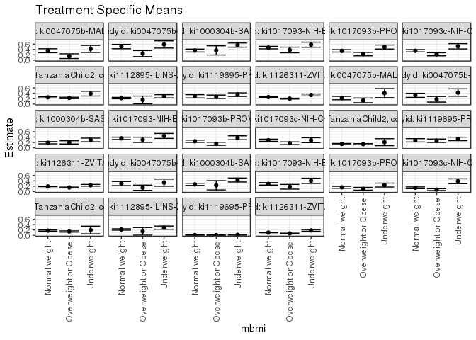

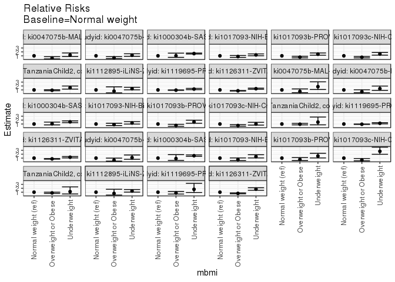

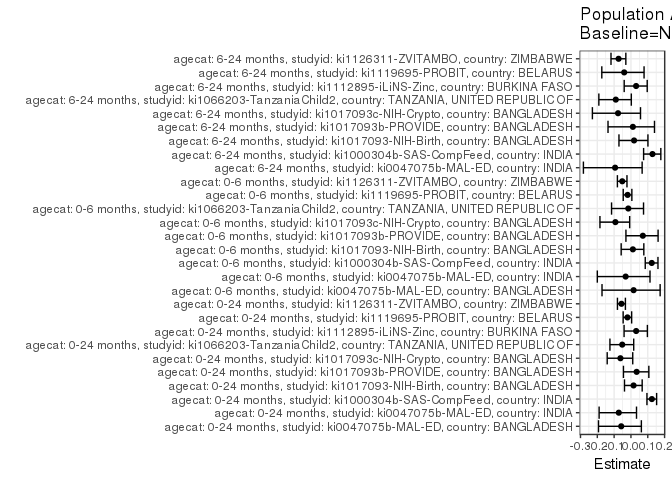

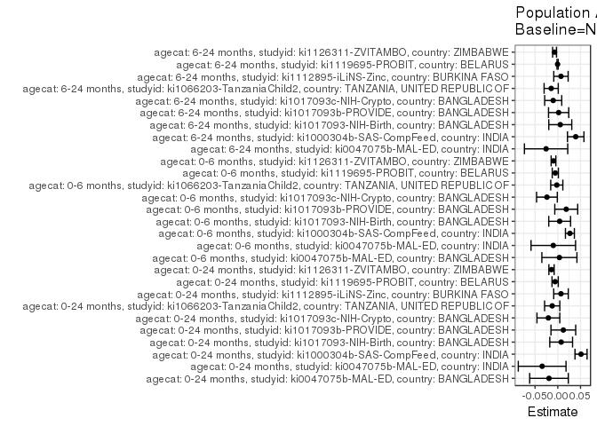

## Results Table

### Parameter: TSM

| agecat | studyid | country | intervention_level | baseline_level | estimate | ci_lower | ci_upper |
| --- | --- | --- | --- | --- | --- | --- | --- |
| 0-24 months | ki0047075b-MAL-ED | BANGLADESH | Normal weight | NA | 0.3540013 | 0.2810565 | 0.4269461 |
| 0-24 months | ki0047075b-MAL-ED | BANGLADESH | Underweight | NA | 0.4220854 | 0.2908449 | 0.5533259 |
| 0-24 months | ki0047075b-MAL-ED | BANGLADESH | Overweight or Obese | NA | 0.1497432 | 0.0624200 | 0.2370664 |
| 0-24 months | ki0047075b-MAL-ED | INDIA | Normal weight | NA | 0.5095815 | 0.4278478 | 0.5913153 |
| 0-24 months | ki0047075b-MAL-ED | INDIA | Underweight | NA | 0.5884013 | 0.4536074 | 0.7231953 |
| 0-24 months | ki0047075b-MAL-ED | INDIA | Overweight or Obese | NA | 0.2479076 | 0.1350495 | 0.3607656 |
| 0-24 months | ki1000304b-SAS-CompFeed | INDIA | Normal weight | NA | 0.3599601 | 0.3054453 | 0.4144748 |
| 0-24 months | ki1000304b-SAS-CompFeed | INDIA | Underweight | NA | 0.5635066 | 0.4859147 | 0.6410986 |
| 0-24 months | ki1000304b-SAS-CompFeed | INDIA | Overweight or Obese | NA | 0.3657463 | 0.1949551 | 0.5365374 |
| 0-24 months | ki1017093-NIH-Birth | BANGLADESH | Normal weight | NA | 0.4701186 | 0.4236763 | 0.5165609 |
| 0-24 months | ki1017093-NIH-Birth | BANGLADESH | Underweight | NA | 0.5781405 | 0.4844308 | 0.6718501 |
| 0-24 months | ki1017093-NIH-Birth | BANGLADESH | Overweight or Obese | NA | 0.3820641 | 0.2769070 | 0.4872212 |
| 0-24 months | ki1017093b-PROVIDE | BANGLADESH | Normal weight | NA | 0.3480476 | 0.3033829 | 0.3927124 |
| 0-24 months | ki1017093b-PROVIDE | BANGLADESH | Underweight | NA | 0.4915608 | 0.4166497 | 0.5664719 |
| 0-24 months | ki1017093b-PROVIDE | BANGLADESH | Overweight or Obese | NA | 0.2279562 | 0.1636099 | 0.2923026 |
| 0-24 months | ki1017093c-NIH-Crypto | BANGLADESH | Normal weight | NA | 0.3518430 | 0.3091723 | 0.3945138 |
| 0-24 months | ki1017093c-NIH-Crypto | BANGLADESH | Underweight | NA | 0.5190794 | 0.4201872 | 0.6179716 |
| 0-24 months | ki1017093c-NIH-Crypto | BANGLADESH | Overweight or Obese | NA | 0.2209882 | 0.1641417 | 0.2778348 |
| 0-24 months | ki1066203-TanzaniaChild2 | TANZANIA, UNITED REPUBLIC OF | Normal weight | NA | 0.2494011 | 0.2251019 | 0.2737003 |
| 0-24 months | ki1066203-TanzaniaChild2 | TANZANIA, UNITED REPUBLIC OF | Underweight | NA | 0.3872075 | 0.2984769 | 0.4759382 |
| 0-24 months | ki1066203-TanzaniaChild2 | TANZANIA, UNITED REPUBLIC OF | Overweight or Obese | NA | 0.2271224 | 0.2017518 | 0.2524930 |
| 0-24 months | ki1112895-iLiNS-Zinc | BURKINA FASO | Normal weight | NA | 0.2201553 | 0.1939821 | 0.2463285 |
| 0-24 months | ki1112895-iLiNS-Zinc | BURKINA FASO | Underweight | NA | 0.2876211 | 0.2272621 | 0.3479802 |
| 0-24 months | ki1112895-iLiNS-Zinc | BURKINA FASO | Overweight or Obese | NA | 0.1513624 | 0.0058102 | 0.2969145 |
| 0-24 months | ki1119695-PROBIT | BELARUS | Normal weight | NA | 0.2875430 | 0.2259158 | 0.3491702 |
| 0-24 months | ki1119695-PROBIT | BELARUS | Underweight | NA | 0.3497780 | 0.2824717 | 0.4170843 |
| 0-24 months | ki1119695-PROBIT | BELARUS | Overweight or Obese | NA | 0.2699939 | 0.2071520 | 0.3328358 |
| 0-24 months | ki1126311-ZVITAMBO | ZIMBABWE | Normal weight | NA | 0.2588855 | 0.2483992 | 0.2693718 |
| 0-24 months | ki1126311-ZVITAMBO | ZIMBABWE | Underweight | NA | 0.3378774 | 0.3019926 | 0.3737622 |
| 0-24 months | ki1126311-ZVITAMBO | ZIMBABWE | Overweight or Obese | NA | 0.2012309 | 0.1855361 | 0.2169258 |

[output cut: 54 more lines]

### Parameter: E(Y)

| agecat | studyid | country | intervention_level | baseline_level | estimate | ci_lower | ci_upper |
| --- | --- | --- | --- | --- | --- | --- | --- |
| 0-24 months | ki0047075b-MAL-ED | BANGLADESH | NA | NA | 0.3346457 | 0.2765014 | 0.3927899 |
| 0-24 months | ki0047075b-MAL-ED | INDIA | NA | NA | 0.4752066 | 0.4121581 | 0.5382551 |
| 0-24 months | ki1000304b-SAS-CompFeed | INDIA | NA | NA | 0.4110871 | 0.3516836 | 0.4704906 |
| 0-24 months | ki1017093-NIH-Birth | BANGLADESH | NA | NA | 0.4775641 | 0.4383415 | 0.5167867 |
| 0-24 months | ki1017093b-PROVIDE | BANGLADESH | NA | NA | 0.3602392 | 0.3238339 | 0.3966444 |
| 0-24 months | ki1017093c-NIH-Crypto | BANGLADESH | NA | NA | 0.3311258 | 0.2975342 | 0.3647175 |
| 0-24 months | ki1066203-TanzaniaChild2 | TANZANIA, UNITED REPUBLIC OF | NA | NA | 0.2371002 | 0.2198828 | 0.2543177 |
| 0-24 months | ki1112895-iLiNS-Zinc | BURKINA FASO | NA | NA | 0.2271869 | 0.2003867 | 0.2539871 |
| 0-24 months | ki1119695-PROBIT | BELARUS | NA | NA | 0.2816871 | 0.2197838 | 0.3435903 |
| 0-24 months | ki1126311-ZVITAMBO | ZIMBABWE | NA | NA | 0.2450750 | 0.2365573 | 0.2535928 |
| 0-6 months | ki0047075b-MAL-ED | BANGLADESH | NA | NA | 0.2244094 | 0.1730022 | 0.2758167 |
| 0-6 months | ki0047075b-MAL-ED | INDIA | NA | NA | 0.3140496 | 0.2554513 | 0.3726479 |
| 0-6 months | ki1000304b-SAS-CompFeed | INDIA | NA | NA | 0.2156295 | 0.1693905 | 0.2618686 |
| 0-6 months | ki1017093-NIH-Birth | BANGLADESH | NA | NA | 0.3569132 | 0.3192325 | 0.3945938 |
| 0-6 months | ki1017093b-PROVIDE | BANGLADESH | NA | NA | 0.2630792 | 0.2296894 | 0.2964690 |
| 0-6 months | ki1017093c-NIH-Crypto | BANGLADESH | NA | NA | 0.2582781 | 0.2270370 | 0.2895193 |
| 0-6 months | ki1066203-TanzaniaChild2 | TANZANIA, UNITED REPUBLIC OF | NA | NA | 0.1402985 | 0.1262390 | 0.1543580 |
| 0-6 months | ki1119695-PROBIT | BELARUS | NA | NA | 0.2746941 | 0.2120609 | 0.3373272 |
| 0-6 months | ki1126311-ZVITAMBO | ZIMBABWE | NA | NA | 0.1824982 | 0.1748345 | 0.1901620 |
| 6-24 months | ki0047075b-MAL-ED | INDIA | NA | NA | 0.2735043 | 0.2162683 | 0.3307402 |
| 6-24 months | ki1000304b-SAS-CompFeed | INDIA | NA | NA | 0.3079937 | 0.2595409 | 0.3564465 |
| 6-24 months | ki1017093-NIH-Birth | BANGLADESH | NA | NA | 0.2939002 | 0.2554778 | 0.3323226 |
| 6-24 months | ki1017093b-PROVIDE | BANGLADESH | NA | NA | 0.1612378 | 0.1321259 | 0.1903497 |
| 6-24 months | ki1017093c-NIH-Crypto | BANGLADESH | NA | NA | 0.1315068 | 0.1069744 | 0.1560393 |
| 6-24 months | ki1066203-TanzaniaChild2 | TANZANIA, UNITED REPUBLIC OF | NA | NA | 0.1612576 | 0.1450216 | 0.1774936 |
| 6-24 months | ki1112895-iLiNS-Zinc | BURKINA FASO | NA | NA | 0.2271869 | 0.2003867 | 0.2539871 |
| 6-24 months | ki1119695-PROBIT | BELARUS | NA | NA | 0.0102770 | 0.0071241 | 0.0134298 |
| 6-24 months | ki1126311-ZVITAMBO | ZIMBABWE | NA | NA | 0.0965066 | 0.0902505 | 0.1027627 |

### Parameter: RR

| agecat | studyid | country | intervention_level | baseline_level | estimate | ci_lower | ci_upper |
| --- | --- | --- | --- | --- | --- | --- | --- |
| 0-24 months | ki0047075b-MAL-ED | BANGLADESH | Normal weight | Normal weight | 1.0000000 | 1.0000000 | 1.0000000 |
| 0-24 months | ki0047075b-MAL-ED | BANGLADESH | Underweight | Normal weight | 1.1923272 | 0.8225148 | 1.7284116 |
| 0-24 months | ki0047075b-MAL-ED | BANGLADESH | Overweight or Obese | Normal weight | 0.4230018 | 0.2282517 | 0.7839177 |
| 0-24 months | ki0047075b-MAL-ED | INDIA | Normal weight | Normal weight | 1.0000000 | 1.0000000 | 1.0000000 |
| 0-24 months | ki0047075b-MAL-ED | INDIA | Underweight | Normal weight | 1.1546756 | 0.8726677 | 1.5278162 |
| 0-24 months | ki0047075b-MAL-ED | INDIA | Overweight or Obese | Normal weight | 0.4864925 | 0.3002408 | 0.7882837 |
| 0-24 months | ki1000304b-SAS-CompFeed | INDIA | Normal weight | Normal weight | 1.0000000 | 1.0000000 | 1.0000000 |
| 0-24 months | ki1000304b-SAS-CompFeed | INDIA | Underweight | Normal weight | 1.5654699 | 1.4425747 | 1.6988347 |
| 0-24 months | ki1000304b-SAS-CompFeed | INDIA | Overweight or Obese | Normal weight | 1.0160745 | 0.6114926 | 1.6883400 |
| 0-24 months | ki1017093-NIH-Birth | BANGLADESH | Normal weight | Normal weight | 1.0000000 | 1.0000000 | 1.0000000 |
| 0-24 months | ki1017093-NIH-Birth | BANGLADESH | Underweight | Normal weight | 1.2297757 | 1.0172935 | 1.4866392 |
| 0-24 months | ki1017093-NIH-Birth | BANGLADESH | Overweight or Obese | Normal weight | 0.8126973 | 0.6068057 | 1.0884488 |
| 0-24 months | ki1017093b-PROVIDE | BANGLADESH | Normal weight | Normal weight | 1.0000000 | 1.0000000 | 1.0000000 |
| 0-24 months | ki1017093b-PROVIDE | BANGLADESH | Underweight | Normal weight | 1.4123377 | 1.1580637 | 1.7224422 |
| 0-24 months | ki1017093b-PROVIDE | BANGLADESH | Overweight or Obese | Normal weight | 0.6549570 | 0.4811810 | 0.8914913 |
| 0-24 months | ki1017093c-NIH-Crypto | BANGLADESH | Normal weight | Normal weight | 1.0000000 | 1.0000000 | 1.0000000 |
| 0-24 months | ki1017093c-NIH-Crypto | BANGLADESH | Underweight | Normal weight | 1.4753154 | 1.1770237 | 1.8492027 |
| 0-24 months | ki1017093c-NIH-Crypto | BANGLADESH | Overweight or Obese | Normal weight | 0.6280876 | 0.4726006 | 0.8347302 |
| 0-24 months | ki1066203-TanzaniaChild2 | TANZANIA, UNITED REPUBLIC OF | Normal weight | Normal weight | 1.0000000 | 1.0000000 | 1.0000000 |
| 0-24 months | ki1066203-TanzaniaChild2 | TANZANIA, UNITED REPUBLIC OF | Underweight | Normal weight | 1.5525493 | 1.2107440 | 1.9908496 |
| 0-24 months | ki1066203-TanzaniaChild2 | TANZANIA, UNITED REPUBLIC OF | Overweight or Obese | Normal weight | 0.9106712 | 0.7852916 | 1.0560689 |
| 0-24 months | ki1112895-iLiNS-Zinc | BURKINA FASO | Normal weight | Normal weight | 1.0000000 | 1.0000000 | 1.0000000 |
| 0-24 months | ki1112895-iLiNS-Zinc | BURKINA FASO | Underweight | Normal weight | 1.3064469 | 1.0199337 | 1.6734454 |
| 0-24 months | ki1112895-iLiNS-Zinc | BURKINA FASO | Overweight or Obese | Normal weight | 0.6875256 | 0.2649284 | 1.7842233 |
| 0-24 months | ki1119695-PROBIT | BELARUS | Normal weight | Normal weight | 1.0000000 | 1.0000000 | 1.0000000 |
| 0-24 months | ki1119695-PROBIT | BELARUS | Underweight | Normal weight | 1.2164372 | 1.0656926 | 1.3885049 |
| 0-24 months | ki1119695-PROBIT | BELARUS | Overweight or Obese | Normal weight | 0.9389688 | 0.8815809 | 1.0000925 |
| 0-24 months | ki1126311-ZVITAMBO | ZIMBABWE | Normal weight | Normal weight | 1.0000000 | 1.0000000 | 1.0000000 |
| 0-24 months | ki1126311-ZVITAMBO | ZIMBABWE | Underweight | Normal weight | 1.3051227 | 1.1649502 | 1.4621615 |
| 0-24 months | ki1126311-ZVITAMBO | ZIMBABWE | Overweight or Obese | Normal weight | 0.7772970 | 0.7119231 | 0.8486740 |

[output cut: 54 more lines]

### Parameter: PAR

| agecat | studyid | country | intervention_level | baseline_level | estimate | ci_lower | ci_upper |
| --- | --- | --- | --- | --- | --- | --- | --- |
| 0-24 months | ki0047075b-MAL-ED | BANGLADESH | Normal weight | NA | -0.0193556 | -0.0618506 | 0.0231394 |
| 0-24 months | ki0047075b-MAL-ED | INDIA | Normal weight | NA | -0.0343749 | -0.0868803 | 0.0181305 |
| 0-24 months | ki1000304b-SAS-CompFeed | INDIA | Normal weight | NA | 0.0511271 | 0.0378448 | 0.0644093 |
| 0-24 months | ki1017093-NIH-Birth | BANGLADESH | Normal weight | NA | 0.0074455 | -0.0176375 | 0.0325285 |
| 0-24 months | ki1017093b-PROVIDE | BANGLADESH | Normal weight | NA | 0.0121915 | -0.0149912 | 0.0393743 |
| 0-24 months | ki1017093c-NIH-Crypto | BANGLADESH | Normal weight | NA | -0.0207172 | -0.0458237 | 0.0043893 |
| 0-24 months | ki1066203-TanzaniaChild2 | TANZANIA, UNITED REPUBLIC OF | Normal weight | NA | -0.0123009 | -0.0290421 | 0.0044403 |
| 0-24 months | ki1112895-iLiNS-Zinc | BURKINA FASO | Normal weight | NA | 0.0070317 | -0.0089697 | 0.0230330 |
| 0-24 months | ki1119695-PROBIT | BELARUS | Normal weight | NA | -0.0058559 | -0.0127301 | 0.0010182 |
| 0-24 months | ki1126311-ZVITAMBO | ZIMBABWE | Normal weight | NA | -0.0138105 | -0.0196105 | -0.0080105 |
| 0-6 months | ki0047075b-MAL-ED | BANGLADESH | Normal weight | NA | 0.0035506 | -0.0350317 | 0.0421328 |
| 0-6 months | ki0047075b-MAL-ED | INDIA | Normal weight | NA | -0.0098941 | -0.0588967 | 0.0391085 |
| 0-6 months | ki1000304b-SAS-CompFeed | INDIA | Normal weight | NA | 0.0266672 | 0.0168443 | 0.0364900 |
| 0-6 months | ki1017093-NIH-Birth | BANGLADESH | Normal weight | NA | 0.0041140 | -0.0199044 | 0.0281324 |
| 0-6 months | ki1017093b-PROVIDE | BANGLADESH | Normal weight | NA | 0.0185936 | -0.0065887 | 0.0437759 |
| 0-6 months | ki1017093c-NIH-Crypto | BANGLADESH | Normal weight | NA | -0.0238573 | -0.0466885 | -0.0010260 |
| 0-6 months | ki1066203-TanzaniaChild2 | TANZANIA, UNITED REPUBLIC OF | Normal weight | NA | -0.0022116 | -0.0155307 | 0.0111075 |
| 0-6 months | ki1119695-PROBIT | BELARUS | Normal weight | NA | -0.0054739 | -0.0122467 | 0.0012989 |
| 0-6 months | ki1126311-ZVITAMBO | ZIMBABWE | Normal weight | NA | -0.0094369 | -0.0146304 | -0.0042433 |
| 6-24 months | ki0047075b-MAL-ED | INDIA | Normal weight | NA | -0.0257658 | -0.0733734 | 0.0218418 |
| 6-24 months | ki1000304b-SAS-CompFeed | INDIA | Normal weight | NA | 0.0394115 | 0.0212895 | 0.0575334 |
| 6-24 months | ki1017093-NIH-Birth | BANGLADESH | Normal weight | NA | 0.0054820 | -0.0198084 | 0.0307724 |
| 6-24 months | ki1017093b-PROVIDE | BANGLADESH | Normal weight | NA | 0.0018484 | -0.0203629 | 0.0240597 |
| 6-24 months | ki1017093c-NIH-Crypto | BANGLADESH | Normal weight | NA | -0.0100880 | -0.0288615 | 0.0086855 |
| 6-24 months | ki1066203-TanzaniaChild2 | TANZANIA, UNITED REPUBLIC OF | Normal weight | NA | -0.0145236 | -0.0301009 | 0.0010536 |
| 6-24 months | ki1112895-iLiNS-Zinc | BURKINA FASO | Normal weight | NA | 0.0069655 | -0.0088263 | 0.0227573 |
| 6-24 months | ki1119695-PROBIT | BELARUS | Normal weight | NA | -0.0004118 | -0.0016851 | 0.0008615 |
| 6-24 months | ki1126311-ZVITAMBO | ZIMBABWE | Normal weight | NA | -0.0071010 | -0.0113630 | -0.0028390 |

### Parameter: PAF

| agecat | studyid | country | intervention_level | baseline_level | estimate | ci_lower | ci_upper |
| --- | --- | --- | --- | --- | --- | --- | --- |
| 0-24 months | ki0047075b-MAL-ED | BANGLADESH | Normal weight | NA | -0.0578392 | -0.1929005 | 0.0619304 |
| 0-24 months | ki0047075b-MAL-ED | INDIA | Normal weight | NA | -0.0723367 | -0.1892629 | 0.0330935 |
| 0-24 months | ki1000304b-SAS-CompFeed | INDIA | Normal weight | NA | 0.1243704 | 0.0951311 | 0.1526648 |
| 0-24 months | ki1017093-NIH-Birth | BANGLADESH | Normal weight | NA | 0.0155905 | -0.0383678 | 0.0667449 |
| 0-24 months | ki1017093b-PROVIDE | BANGLADESH | Normal weight | NA | 0.0338429 | -0.0445939 | 0.1063900 |
| 0-24 months | ki1017093c-NIH-Crypto | BANGLADESH | Normal weight | NA | -0.0625659 | -0.1411929 | 0.0106438 |
| 0-24 months | ki1066203-TanzaniaChild2 | TANZANIA, UNITED REPUBLIC OF | Normal weight | NA | -0.0518806 | -0.1249241 | 0.0164199 |
| 0-24 months | ki1112895-iLiNS-Zinc | BURKINA FASO | Normal weight | NA | 0.0309509 | -0.0408728 | 0.0978186 |
| 0-24 months | ki1119695-PROBIT | BELARUS | Normal weight | NA | -0.0207888 | -0.0463567 | 0.0041544 |
| 0-24 months | ki1126311-ZVITAMBO | ZIMBABWE | Normal weight | NA | -0.0563522 | -0.0802918 | -0.0329430 |
| 0-6 months | ki0047075b-MAL-ED | BANGLADESH | Normal weight | NA | 0.0158218 | -0.1720176 | 0.1735561 |
| 0-6 months | ki0047075b-MAL-ED | INDIA | Normal weight | NA | -0.0315048 | -0.1999522 | 0.1132962 |
| 0-6 months | ki1000304b-SAS-CompFeed | INDIA | Normal weight | NA | 0.1236712 | 0.0850623 | 0.1606509 |
| 0-6 months | ki1017093-NIH-Birth | BANGLADESH | Normal weight | NA | 0.0115265 | -0.0581167 | 0.0765859 |
| 0-6 months | ki1017093b-PROVIDE | BANGLADESH | Normal weight | NA | 0.0706769 | -0.0298260 | 0.1613715 |
| 0-6 months | ki1017093c-NIH-Crypto | BANGLADESH | Normal weight | NA | -0.0923705 | -0.1843387 | -0.0075439 |
| 0-6 months | ki1066203-TanzaniaChild2 | TANZANIA, UNITED REPUBLIC OF | Normal weight | NA | -0.0157636 | -0.1152660 | 0.0748613 |
| 0-6 months | ki1119695-PROBIT | BELARUS | Normal weight | NA | -0.0199273 | -0.0459189 | 0.0054183 |
| 0-6 months | ki1126311-ZVITAMBO | ZIMBABWE | Normal weight | NA | -0.0517093 | -0.0805400 | -0.0236479 |
| 6-24 months | ki0047075b-MAL-ED | INDIA | Normal weight | NA | -0.0942062 | -0.2826501 | 0.0665520 |
| 6-24 months | ki1000304b-SAS-CompFeed | INDIA | Normal weight | NA | 0.1279619 | 0.0752752 | 0.1776467 |
| 6-24 months | ki1017093-NIH-Birth | BANGLADESH | Normal weight | NA | 0.0186526 | -0.0712588 | 0.1010176 |
| 6-24 months | ki1017093b-PROVIDE | BANGLADESH | Normal weight | NA | 0.0114638 | -0.1363212 | 0.1400286 |
| 6-24 months | ki1017093c-NIH-Crypto | BANGLADESH | Normal weight | NA | -0.0767110 | -0.2292102 | 0.0568687 |
| 6-24 months | ki1066203-TanzaniaChild2 | TANZANIA, UNITED REPUBLIC OF | Normal weight | NA | -0.0900649 | -0.1908023 | 0.0021506 |
| 6-24 months | ki1112895-iLiNS-Zinc | BURKINA FASO | Normal weight | NA | 0.0306597 | -0.0401997 | 0.0966920 |
| 6-24 months | ki1119695-PROBIT | BELARUS | Normal weight | NA | -0.0400698 | -0.1732473 | 0.0779904 |
| 6-24 months | ki1126311-ZVITAMBO | ZIMBABWE | Normal weight | NA | -0.0735809 | -0.1185842 | -0.0303882 |